# Bugs

Phạm Phương Thảo

8/19/2021

```
## here() starts at C:/Users/KimLoai/Documents/R project/most_frequent_words
```

# no lines available in input

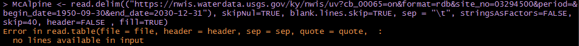

[Stackoverflow](https://stackoverflow.com/questions/50275240/r-read-delim-error-no-lines-available-in-input)

Thông thường lỗi này xuất hiện là do file mà bạn import không chứa dữ liệu hoặc do dữ liệu có vấn đề. Tuy nhiên, file dữ liệu của mình hoàn toàn ổn. Khi mình mở một project khác, sử dụng code và dữ liệu y hệt thì lại không xảy ra lỗi. Minh giải quyết bằng cách là thoát hết các file đang được mở của project, sau đó mình thoát project rồi mở lại. Chạy bình thường. Mình muốn nói thêm về lí do tại sao mình không dùng cách này ngay từ ban đầu. Bởi vì mình dịch tự động có liên quan đến cái API nên khi đóng phiên làm việc của mình, object sẽ bị mất và mình phải tải lại. Lúc đó nó sẽ tính vào cái API của mình.

# read.csv warning ‘EOF within quoted string’

Lỗi này xảy ra là do trong file dữ liệu của bạn có xuất hiện dấu `"`, tức R sẽ hiểu đây là bắt đầu của trích dẫn. Để giải quyết thì phải thiết lập `read.csv(quote = "").

# R Error in scan: Line 1 did nothave X Elements

Lỗi này xảy ra do dữ liệu mà bạn đưa vào có một ô nào đấy bị khuyết dữ liệu. Giải quyết bằng cách thiết lập tham số `read.xxx(fill = TRUE)`.

Một trường hợp nữa mà mình gặp có liên quan đến tham số `quote`. Xem ví dụ sau đây:

```
##   a  b    d
## 1 d  w    p
## 2 f  e   na
## 3 g na   na
## 4 h  r u, i
```